# How to work with Seurat objects

Author

Marc Elosua Bayes

Published

February 9, 2024

## Introduction

In this vignette we are going to show how to work with `Seurat` objects. We will go over how the object is structured, how to access the different data types stored in it and provide some examples of how to do so. We will be doing this on the `3K PBMC` dataset from 10X genomics and the `Broad Institute PBMC Systematic Comparative Analysis`. By the end of this script you will be able to:

1. Access the different data contained within a `Seurat` object
2. Merge multiple `Seurat` objects
3. Access the raw, normalized, and scaled counts
4. Extract the highly variable genes (HVG)
5. Subset to a specific gene or cell subset
6. Access the PCA and UMAP loadings

This is not an exhaustive vignette of everything going on within the Seurat object. More extensive resources can be found in Seurat’s [essential commands vignette](https://satijalab.org/seurat/articles/seurat5_essential_commands)

## Libraries

Load the libraries and install the packages needed to run this notebook

```r
library(tidyverse)
library(Seurat)
library(SeuratData)

# install tutorial data if it doesn't exist
if (!require("pbmc3k.SeuratData", character.only = TRUE))
    install.packages(
        "https://seurat.nygenome.org/src/contrib/pbmc3k.SeuratData_3.1.4.tar.gz",
        repos = NULL,
        type = "source")

# install tutorial data if it doesn't exist
if (!require("pbmcsca.SeuratData", character.only = TRUE))
    install.packages(
        "https://seurat.nygenome.org/src/contrib/pbmcsca.SeuratData_3.0.0.tar.gz",
        repos = NULL,
        type = "source")

library(pbmc3k.SeuratData)
library(pbmcsca.SeuratData)

# Remember to set a seed so the analysis is reproducible!
set.seed(687)
```

## Load data

Lets load the data and take a peek at what they have stored for us!

```r
data(pbmc3k)
# since we are working with Seurat V5 we need to do one extra step - you won't need to do this if you're creating your object from scratch
pbmc3k <- UpdateSeuratObject(pbmc3k)
```

```
Validating object structure
```

```
Updating object slots
```

```
Ensuring keys are in the proper structure
Ensuring keys are in the proper structure
```

```
Ensuring feature names don't have underscores or pipes
```

```
Updating slots in RNA
```

```
Validating object structure for Assay 'RNA'
```

```
Object representation is consistent with the most current Seurat version
```

```r
pbmc3k
```

```
An object of class Seurat
13714 features across 2700 samples within 1 assay
Active assay: RNA (13714 features, 0 variable features)
 2 layers present: counts, data
```

Right of the bat, we see how this is an object of class Seurat and has 13.714 genes and 2.700 cells. It also has an RNA assay - which contains our gene expression matrix that stores 2 layers. `counts` for the raw/unnormalized gene expression data and `data` for normalized gene expression data.

```r
data(pbmcsca)
pbmcsca <- UpdateSeuratObject(pbmcsca)
```

```
Validating object structure
```

```
Updating object slots
```

```
Ensuring keys are in the proper structure
Ensuring keys are in the proper structure
```

```
Ensuring feature names don't have underscores or pipes
```

```
Updating slots in RNA
```

```
Validating object structure for Assay 'RNA'
```

```
Object representation is consistent with the most current Seurat version
```

```r
pbmcsca
```

```
An object of class Seurat
33694 features across 31021 samples within 1 assay
Active assay: RNA (33694 features, 0 variable features)
 2 layers present: counts, data
```

In turn, the `pbmcsca` object has 33.694 genes and 31.021 cells and the same structure as the `pbmc3k` object

## Accessing cell-associated metadata

The cell metadata contains information related to each cell. This information includes information regarding the sample or patient it comes from: disease, condition, date of collection, batch… and information specific for that cell: cell type, number of UMI counts, number of genes detected, mitochondrial % …

To access this information we need to access the metadata, we can do this with the `@metadata` accessor.

```r
# Use head to only visualize the information of the first 5 cells
head(pbmc3k@meta.data)
```

```
               orig.ident nCount_RNA nFeature_RNA seurat_annotations
AAACATACAACCAC     pbmc3k       2419          779       Memory CD4 T
AAACATTGAGCTAC     pbmc3k       4903         1352                  B
AAACATTGATCAGC     pbmc3k       3147         1129       Memory CD4 T
AAACCGTGCTTCCG     pbmc3k       2639          960         CD14+ Mono
AAACCGTGTATGCG     pbmc3k        980          521                 NK
AAACGCACTGGTAC     pbmc3k       2163          781       Memory CD4 T
```

```r
head(pbmcsca@meta.data)
```

```
                   orig.ident nCount_RNA nFeature_RNA nGene   nUMI
pbmc1_SM2_Cell_108      pbmc1     437125         2200  2200 437125
pbmc1_SM2_Cell_115      pbmc1     335596         2438  2438 335596
pbmc1_SM2_Cell_133      pbmc1     302204         1874  1874 302204
pbmc1_SM2_Cell_142      pbmc1     377420         2480  2480 377420
pbmc1_SM2_Cell_143      pbmc1     385514         2196  2196 385514
pbmc1_SM2_Cell_144      pbmc1     304994         2216  2216 304994
                         percent.mito Cluster         CellType Experiment
pbmc1_SM2_Cell_108 0.0297434465355702       0 Cytotoxic T cell      pbmc1
pbmc1_SM2_Cell_115 0.0311521658159055       0 Cytotoxic T cell      pbmc1
pbmc1_SM2_Cell_133 0.0431128105727693       0 Cytotoxic T cell      pbmc1
pbmc1_SM2_Cell_142 0.0260323569927476       0 Cytotoxic T cell      pbmc1
pbmc1_SM2_Cell_143 0.0404759383962183       0 Cytotoxic T cell      pbmc1
pbmc1_SM2_Cell_144  0.023409951391094       0 Cytotoxic T cell      pbmc1
                       Method
pbmc1_SM2_Cell_108 Smart-seq2
pbmc1_SM2_Cell_115 Smart-seq2
pbmc1_SM2_Cell_133 Smart-seq2
pbmc1_SM2_Cell_142 Smart-seq2
pbmc1_SM2_Cell_143 Smart-seq2
pbmc1_SM2_Cell_144 Smart-seq2
```

We can access a specific column like this:

```r
head(pbmcsca[["nGene"]])
```

```
                   nGene
pbmc1_SM2_Cell_108  2200
pbmc1_SM2_Cell_115  2438
pbmc1_SM2_Cell_133  1874
pbmc1_SM2_Cell_142  2480
pbmc1_SM2_Cell_143  2196
pbmc1_SM2_Cell_144  2216
```

```r
head(pbmcsca$nGene)
```

```
pbmc1_SM2_Cell_108 pbmc1_SM2_Cell_115 pbmc1_SM2_Cell_133 pbmc1_SM2_Cell_142
            "2200"             "2438"             "1874"             "2480"
pbmc1_SM2_Cell_143 pbmc1_SM2_Cell_144
            "2196"             "2216"
```

```r
head(pbmcsca@meta.data$nGene)
```

```
[1] "2200" "2438" "1874" "2480" "2196" "2216"
```

We can see how in the `pbmc3k` object we have 4 features associated to each cell. For `pbmcsca`, in turn we have 10. Out of these 2 we see how there are some redundancies - `nCount_RNA` == `nUMI` and `nFeature_RNA` == `nGene`. We can remove redundant columns as follows:

```r
pbmcsca[["nGene"]] <- NULL
pbmcsca[["nUMI"]] <- NULL
head(pbmcsca)
```

```
                   orig.ident nCount_RNA nFeature_RNA       percent.mito
pbmc1_SM2_Cell_108      pbmc1     437125         2200 0.0297434465355702
pbmc1_SM2_Cell_115      pbmc1     335596         2438 0.0311521658159055
pbmc1_SM2_Cell_133      pbmc1     302204         1874 0.0431128105727693
pbmc1_SM2_Cell_142      pbmc1     377420         2480 0.0260323569927476
pbmc1_SM2_Cell_143      pbmc1     385514         2196 0.0404759383962183
pbmc1_SM2_Cell_144      pbmc1     304994         2216  0.023409951391094
pbmc1_SM2_Cell_146      pbmc1     410522         2331 0.0266065031418581
pbmc1_SM2_Cell_148      pbmc1     335187         2075 0.0446061115049967
pbmc1_SM2_Cell_152      pbmc1     485530         2830 0.0234517593805909
pbmc1_SM2_Cell_153      pbmc1     280213         2263 0.0346036948333838
                   Cluster         CellType Experiment     Method
pbmc1_SM2_Cell_108       0 Cytotoxic T cell      pbmc1 Smart-seq2
pbmc1_SM2_Cell_115       0 Cytotoxic T cell      pbmc1 Smart-seq2
pbmc1_SM2_Cell_133       0 Cytotoxic T cell      pbmc1 Smart-seq2
pbmc1_SM2_Cell_142       0 Cytotoxic T cell      pbmc1 Smart-seq2
pbmc1_SM2_Cell_143       0 Cytotoxic T cell      pbmc1 Smart-seq2
pbmc1_SM2_Cell_144       0 Cytotoxic T cell      pbmc1 Smart-seq2
pbmc1_SM2_Cell_146       0 Cytotoxic T cell      pbmc1 Smart-seq2
pbmc1_SM2_Cell_148       0 Cytotoxic T cell      pbmc1 Smart-seq2
pbmc1_SM2_Cell_152       5 Cytotoxic T cell      pbmc1 Smart-seq2
pbmc1_SM2_Cell_153       0 Cytotoxic T cell      pbmc1 Smart-seq2
```

We can also add metadata of interest - for example log1p of nCount_RNA”

```r
pbmc3k[["log1p_nCount_RNA"]] <- log1p(pbmc3k[["nCount_RNA"]])
pbmcsca[["log1p_nCount_RNA"]] <- log1p(pbmcsca[["nCount_RNA"]])
head(pbmcsca@meta.data)
```

```
                   orig.ident nCount_RNA nFeature_RNA       percent.mito
pbmc1_SM2_Cell_108      pbmc1     437125         2200 0.0297434465355702
pbmc1_SM2_Cell_115      pbmc1     335596         2438 0.0311521658159055
pbmc1_SM2_Cell_133      pbmc1     302204         1874 0.0431128105727693
pbmc1_SM2_Cell_142      pbmc1     377420         2480 0.0260323569927476
pbmc1_SM2_Cell_143      pbmc1     385514         2196 0.0404759383962183
pbmc1_SM2_Cell_144      pbmc1     304994         2216  0.023409951391094
                   Cluster         CellType Experiment     Method
pbmc1_SM2_Cell_108       0 Cytotoxic T cell      pbmc1 Smart-seq2
pbmc1_SM2_Cell_115       0 Cytotoxic T cell      pbmc1 Smart-seq2
pbmc1_SM2_Cell_133       0 Cytotoxic T cell      pbmc1 Smart-seq2
pbmc1_SM2_Cell_142       0 Cytotoxic T cell      pbmc1 Smart-seq2
pbmc1_SM2_Cell_143       0 Cytotoxic T cell      pbmc1 Smart-seq2
pbmc1_SM2_Cell_144       0 Cytotoxic T cell      pbmc1 Smart-seq2
                   log1p_nCount_RNA
pbmc1_SM2_Cell_108         12.98798
pbmc1_SM2_Cell_115         12.72367
pbmc1_SM2_Cell_133         12.61886
pbmc1_SM2_Cell_142         12.84112
pbmc1_SM2_Cell_143         12.86234
pbmc1_SM2_Cell_144         12.62805
```

## Merging Seurat objects

Merging `Seurat` objects is a typical set in many analysis. To do it we can simply use the merge function:

```r
se <- merge(x = pbmc3k, y = pbmcsca)
se
```

```
An object of class Seurat
34231 features across 33721 samples within 1 assay
Active assay: RNA (34231 features, 0 variable features)
 2 layers present: counts, data
```

We can see how we now have a larger object with 34.231 genes and 33.721 cells.

If we were merging more than 2 Seurat objects the 2nd argument of the merge function needs to be a list with all the seurat objects except the one passed to the first argument:

```r
# This is an example code and we are not storing the output anywhere
merge(x = pbmc3k, y = list(pbmcsca, pbmc_small))
```

```
An object of class Seurat
34231 features across 33801 samples within 1 assay
Active assay: RNA (34231 features, 0 variable features)
 2 layers present: counts, data
```

```r
head(se@meta.data)
```

```
               orig.ident nCount_RNA nFeature_RNA seurat_annotations
AAACATACAACCAC     pbmc3k       2419          779       Memory CD4 T
AAACATTGAGCTAC     pbmc3k       4903         1352                  B
AAACATTGATCAGC     pbmc3k       3147         1129       Memory CD4 T
AAACCGTGCTTCCG     pbmc3k       2639          960         CD14+ Mono
AAACCGTGTATGCG     pbmc3k        980          521                 NK
AAACGCACTGGTAC     pbmc3k       2163          781       Memory CD4 T
               log1p_nCount_RNA percent.mito Cluster CellType Experiment Method
AAACATACAACCAC         7.791523         <NA>    <NA>     <NA>       <NA>   <NA>
AAACATTGAGCTAC         8.497806         <NA>    <NA>     <NA>       <NA>   <NA>
AAACATTGATCAGC         8.054523         <NA>    <NA>     <NA>       <NA>   <NA>
AAACCGTGCTTCCG         7.878534         <NA>    <NA>     <NA>       <NA>   <NA>
AAACCGTGTATGCG         6.888572         <NA>    <NA>     <NA>       <NA>   <NA>
AAACGCACTGGTAC         7.679714         <NA>    <NA>     <NA>       <NA>   <NA>
```

```r
tail(se@meta.data)
```

```
                                           orig.ident nCount_RNA nFeature_RNA
pbmc2_inDrops_1_TAGATCAA.TTATGCGA.CTTCGCAC      pbmc2        807          556
pbmc2_inDrops_1_TAGTCTCT.GAGCCTTA.ATCCGCTA      pbmc2        717          453
pbmc2_inDrops_1_TCCAGAAG.TTATGCGA.TAAGACGG      pbmc2        938          592
pbmc2_inDrops_1_TGAATCCT.GAGCCTTA.CCCAAGCA      pbmc2        662          406
pbmc2_inDrops_1_TGAATCCT.TTATGCGA.CATCTCCC      pbmc2       2066         1001
pbmc2_inDrops_1_TGAGCACA.GAGCCTTA.CGAGTCTG      pbmc2        253          184
                                           seurat_annotations log1p_nCount_RNA
pbmc2_inDrops_1_TAGATCAA.TTATGCGA.CTTCGCAC               <NA>         6.694562
pbmc2_inDrops_1_TAGTCTCT.GAGCCTTA.ATCCGCTA               <NA>         6.576470
pbmc2_inDrops_1_TCCAGAAG.TTATGCGA.TAAGACGG               <NA>         6.844815
pbmc2_inDrops_1_TGAATCCT.GAGCCTTA.CCCAAGCA               <NA>         6.496775
pbmc2_inDrops_1_TGAATCCT.TTATGCGA.CATCTCCC               <NA>         7.633854
pbmc2_inDrops_1_TGAGCACA.GAGCCTTA.CGAGTCTG               <NA>         5.537334
                                                 percent.mito Cluster
pbmc2_inDrops_1_TAGATCAA.TTATGCGA.CTTCGCAC 0.0247831474597274       7
pbmc2_inDrops_1_TAGTCTCT.GAGCCTTA.ATCCGCTA  0.097629009762901      11
pbmc2_inDrops_1_TCCAGAAG.TTATGCGA.TAAGACGG  0.035181236673774      11
pbmc2_inDrops_1_TGAATCCT.GAGCCTTA.CCCAAGCA  0.138972809667674      11
pbmc2_inDrops_1_TGAATCCT.TTATGCGA.CATCTCCC 0.0556631171345595      11
pbmc2_inDrops_1_TGAGCACA.GAGCCTTA.CGAGTCTG  0.146245059288538      11
                                                              CellType
pbmc2_inDrops_1_TAGATCAA.TTATGCGA.CTTCGCAC              Dendritic cell
pbmc2_inDrops_1_TAGTCTCT.GAGCCTTA.ATCCGCTA Plasmacytoid dendritic cell
pbmc2_inDrops_1_TCCAGAAG.TTATGCGA.TAAGACGG Plasmacytoid dendritic cell
pbmc2_inDrops_1_TGAATCCT.GAGCCTTA.CCCAAGCA Plasmacytoid dendritic cell
pbmc2_inDrops_1_TGAATCCT.TTATGCGA.CATCTCCC Plasmacytoid dendritic cell
pbmc2_inDrops_1_TGAGCACA.GAGCCTTA.CGAGTCTG Plasmacytoid dendritic cell
                                           Experiment  Method
pbmc2_inDrops_1_TAGATCAA.TTATGCGA.CTTCGCAC      pbmc2 inDrops
pbmc2_inDrops_1_TAGTCTCT.GAGCCTTA.ATCCGCTA      pbmc2 inDrops
pbmc2_inDrops_1_TCCAGAAG.TTATGCGA.TAAGACGG      pbmc2 inDrops
pbmc2_inDrops_1_TGAATCCT.GAGCCTTA.CCCAAGCA      pbmc2 inDrops
pbmc2_inDrops_1_TGAATCCT.TTATGCGA.CATCTCCC      pbmc2 inDrops
pbmc2_inDrops_1_TGAGCACA.GAGCCTTA.CGAGTCTG      pbmc2 inDrops
```

Since we want to have one column where all the column names are the same we can make use of the tidyverse and do the following:

```r
se@meta.data <- se@meta.data %>%
    mutate(
        annotation = if_else(is.na(seurat_annotations), CellType, seurat_annotations))

table(se@meta.data$annotation, useNA = "ifany")
```

```
                          B                      B cell
                        344                        5020
                 CD14+ Mono              CD14+ monocyte
                        480                        5550
             CD16+ monocyte                 CD4+ T cell
                        804                        7391
                      CD8 T            Cytotoxic T cell
                        271                        9071
                         DC              Dendritic cell
                         32                         433
               FCGR3A+ Mono               Megakaryocyte
                        162                         977
               Memory CD4 T                 Naive CD4 T
                        483                         697
        Natural killer cell                          NK
                       1565                         155
Plasmacytoid dendritic cell                    Platelet
                        164                          14
                 Unassigned                        <NA>
                         46                          62
```

```r
# after doing table we still see 62 NA but they were already there in the pbmc3k dataset
table(pbmc3k@meta.data$seurat_annotations, useNA = "ifany")
```

```
 Naive CD4 T Memory CD4 T   CD14+ Mono            B        CD8 T FCGR3A+ Mono
         697          483          480          344          271          162
          NK           DC     Platelet         <NA>
         155           32           14           62
```

## Accessing gene expression data

This is a non-essential but it is good to know to have a better understanding of how Seurat objects work and what data we are using at each step. Gene expression data is usually stored in the RNA Assay:

```r
se@assays
```

```
$RNA
Assay data with 34231 features for 33721 cells
First 10 features:
 AL627309.1, AP006222.2, RP11-206L10.2, RP11-206L10.9, LINC00115, NOC2L,
KLHL17, PLEKHN1, RP11-54O7.17, HES4
```

Lets quickly process the object to have normalized and scaled data

```r
se <- NormalizeData(se, assay = "RNA", normalization.method = "LogNormalize", scale.factor = 10000)
se <- FindVariableFeatures(se, selection.method = "vst", nfeatures = 3000)
se <- ScaleData(se, features = VariableFeatures(se))
```

Within each assay we will have the raw, normalized, and scaled data:

```r
# counts contains the raw gene expression counts
se@assays$RNA@counts[1:5, 1:5]
```

```
5 x 5 sparse Matrix of class "dgCMatrix"
              AAACATACAACCAC AAACATTGAGCTAC AAACATTGATCAGC AAACCGTGCTTCCG
AL627309.1                 .              .              .              .
AP006222.2                 .              .              .              .
RP11-206L10.2              .              .              .              .
RP11-206L10.9              .              .              .              .
LINC00115                  .              .              .              .
              AAACCGTGTATGCG
AL627309.1                 .
AP006222.2                 .
RP11-206L10.2              .
RP11-206L10.9              .
LINC00115                  .
```

```r
# data contains the normalized gene expression
se@assays$RNA@data[1:5, 1:5]
```

```
5 x 5 sparse Matrix of class "dgCMatrix"
              AAACATACAACCAC AAACATTGAGCTAC AAACATTGATCAGC AAACCGTGCTTCCG
AL627309.1                 .              .              .              .
AP006222.2                 .              .              .              .
RP11-206L10.2              .              .              .              .
RP11-206L10.9              .              .              .              .
LINC00115                  .              .              .              .
              AAACCGTGTATGCG
AL627309.1                 .
AP006222.2                 .
RP11-206L10.2              .
RP11-206L10.9              .
LINC00115                  .
```

```r
# scale.data contains the scaled normalized data, usually for the HVG
se@assays$RNA@scale.data[1:5, 1:5]
```

```
         AAACATACAACCAC AAACATTGAGCTAC AAACATTGATCAGC AAACCGTGCTTCCG
KLHL17      -0.06014437    -0.06014437    -0.06014437    -0.06014437
C1orf159    -0.08417976    -0.08417976    -0.08417976    -0.08417976
TNFRSF18    -0.13070452     6.95911242    -0.13070452    -0.13070452
PUSL1       -0.11607955    -0.11607955    -0.11607955    -0.11607955
PLCH2       -0.08098931    -0.08098931    -0.08098931    -0.08098931
         AAACCGTGTATGCG
KLHL17      -0.06014437
C1orf159    -0.08417976
TNFRSF18    -0.13070452
PUSL1       -0.11607955
PLCH2       -0.08098931
```

## PCA and UMAP data

Quick processing to compute PCA and UMAP

```r
se <- RunPCA(se, assay = "RNA", features = VariableFeatures(se))
```

```
PC_ 1
Positive:  LYZ, S100A9, FCN1, VCAN, CTSS, PSAP, SERPINA1, GRN, CD68, CD14
       NCF2, COTL1, CSF3R, MS4A6A, MNDA, FOS, CPVL, MPEG1, DUSP6, SAT1
       TKT, HCK, RGS2, FTL, TGFBI, SLC11A1, PLAUR, GPX1, CTSB, NAMPT
Negative:  CCL5, NKG7, RPL3, IL7R, GZMH, GNLY, FGFBP2, KLRD1, PRF1, CD8A
       CXCR4, GZMB, KLRB1, CD8B, TRDC, SYTL3, SPON2, TSC22D3, B2M, GZMK
       CCR7, ABLIM1, HLA-E, RPL4, LEF1, PLEKHF1, EEF1A1, RP11-291B21.2, NUCB2, MYOM2
PC_ 2
Positive:  EEF1A1, RPL3, CD74, RPL4, TXNIP, HLA-DRA, DDX5, HLA-DRB1, HLA-DPB1, HLA-DPA1
       DUSP1, CTSS, CXCR4, MS4A1, IGHM, HLA-DMB, FOS, LCP1, UBC, SELL
       NFKBIA, ITGB2, BANK1, IGKC, IRF8, TKT, LYZ, LTA4H, ANXA2, PSAP
Negative:  PF4, PPBP, SDPR, TUBB1, GNG11, HIST1H2AC, SPARC, CLU, MAP3K7CL, ACRBP
       RGS18, TREML1, PGRMC1, PRKAR2B, GP9, ITGA2B, MARCH2, TSC22D1, C6orf25, F13A1
       CTTN, CMTM5, HIST1H3H, NXF3, CD9, NGFRAP1, HIST1H2BJ, GPX1, PTCRA, NCOA4
PC_ 3
Positive:  NKG7, CCL5, GZMH, FGFBP2, GNLY, PRF1, GZMB, KLRD1, B2M, ITGB2
       CD8A, SPON2, GAPDH, KLRB1, SYTL3, FCGR3A, TRDC, CD8B, LCP1, TNFAIP3
       HSPA5, ACTB, PLEKHF1, UBC, MYOM2, ITGB1, CX3CR1, ACTG1, IFITM3, SH2D1B
Negative:  MS4A1, IGHM, BANK1, HLA-DRA, IGKC, CD74, TCL1A, HLA-DRB1, IGLC2, HLA-DPA1
       HLA-DPB1, IGLC3, HLA-DMB, FCRL1, ADAM28, IGHG1, JCHAIN, IRF8, CD19, CD24
       FCRLA, FCER2, FCRL5, KIAA0125, KIAA0226L, TLR10, CD180, CDCA7L, CD72, IGHA1
PC_ 4
Positive:  LYZ, S100A9, FCN1, FOS, VCAN, G0S2, DUSP1, CD14, SLC8A1-AS1, TAOK1
       IL1B, SGK1, THBS1, RGS2, CYP1B1, NAMPT, NFKBIA, DUSP6, APOBEC3A, CSF3R
       ID1, QPCT, FPR1, PLAUR, AGBL2, LEF1, SERPINA1, ANPEP, MS4A6A, CRB1
Negative:  CH507-513H4.3, HLA-E, ACTG1, DDX5, UBC, PRF1, KLRD1, HLA-DPA1, ITGB2, FGFBP2
       HLA-DPB1, RPL3, LCP1, RPL4, CTD-2139B15.2, NKG7, GAPDH, GZMB, MT-CO1, MYOM2
       TXNIP, GZMH, SPON2, MTRNR2L8, FCGR3A, CX3CR1, TPM4, GNLY, B2M, TAGLN2
PC_ 5
Positive:  GZMB, NKG7, FGFBP2, GZMH, GNLY, PRF1, SPON2, KLRD1, FCGR3A, CCL5
       HLA-DPB1, HLA-DRB1, HLA-DPA1, CD74, HLA-DRA, MT-CO1, TRDC, MYOM2, ITGB2, PLEKHF1
       SH2D1B, CX3CR1, ACTB, B2M, MS4A1, IGHM, TCL1A, IGKC, IGLC2, IGLC3
Negative:  IL7R, LEF1, CCR7, ITGA6, RPL4, DPP4, LRRN3, MTRNR2L12, EPHX2, ABLIM1
       SELL, TMEM204, EEF1A1, GPR183, UBASH3A, ANK3, MTRNR2L8, TNFAIP3, LGALS3BP, ICOS
       CD4, CH507-513H4.3, HIVEP2, ACTN1, NUCB2, GZMK, TNFSF8, NGFRAP1, PLEKHB1, UXS1
```

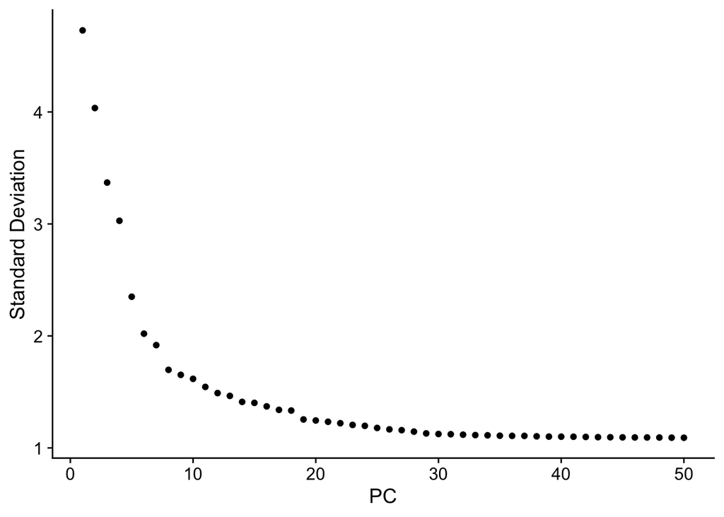

```r
ElbowPlot(se, ndims = 50)
```

```r
se <- RunUMAP(se, dims = 1:30)
```

At this step we can look at the UMAP and the annotations

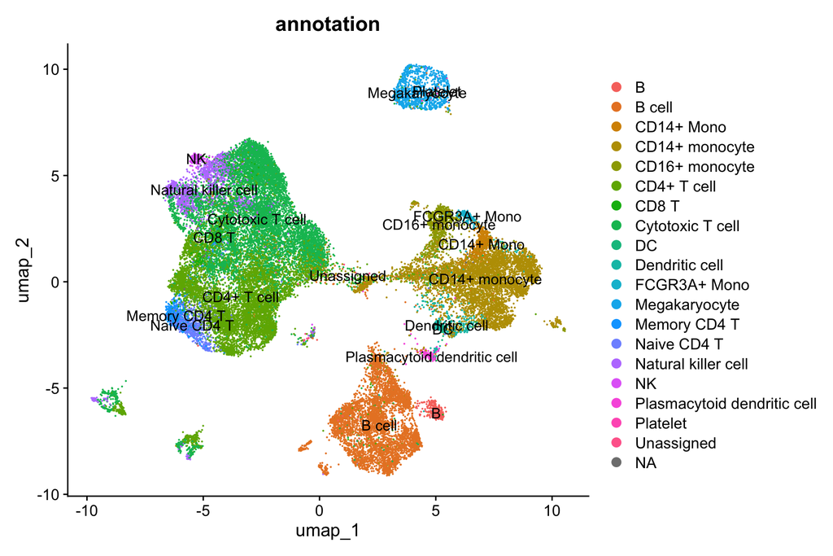

```r
Seurat::DimPlot(
    se,
    group.by = "annotation",
    label = TRUE,
    shuffle = TRUE)
```

Let’s see where this data is stored

```r
se@reductions
```

```
$pca
A dimensional reduction object with key PC_
 Number of dimensions: 50
 Number of cells: 33721
 Projected dimensional reduction calculated:  FALSE
 Jackstraw run: FALSE
 Computed using assay: RNA

$umap
A dimensional reduction object with key umap_
 Number of dimensions: 2
 Number of cells: 33721
 Projected dimensional reduction calculated:  FALSE
 Jackstraw run: FALSE
 Computed using assay: RNA
```

PCA loadings are stored here

```r
# Cell embeddings where we get the PCA loadings for each cell
se@reductions$pca@cell.embeddings[1:5, 1:5]
```

```
                     PC_1       PC_2       PC_3       PC_4       PC_5
AAACATACAACCAC -1.8938529  0.1782632  1.8892620  1.4595055 -0.2693756
AAACATTGAGCTAC  0.4882922  0.6050292 -4.8308856 -0.8160278  2.2330079
AAACATTGATCAGC -0.8030524 -0.2794354  1.1036499  1.1068278 -1.3903541
AAACCGTGCTTCCG  9.0787017  0.4987683  0.4243336  1.4344279  2.4342950
AAACCGTGTATGCG -2.3850467  0.3939542  3.9765326  0.2705033  6.0093788
```

```r
# Gene loadings for each principal component
se@reductions$pca@feature.loadings[1:5, 1:5]
```

```
              PC_1        PC_2        PC_3         PC_4         PC_5
IGHM   -0.01906457  0.03490361 -0.19658826 -0.042994857  0.067569331
THBS1   0.07060157 -0.01503061  0.01605163  0.017706922 -0.019234166
PPBP    0.01400000 -0.19863935 -0.02367305 -0.004379272  0.010082241
SPARC   0.01396970 -0.17372104 -0.01995726 -0.014134988  0.004467159
TREML1  0.01034739 -0.14023328 -0.01678791 -0.015676161  0.005289009
```

Now the UMAP loadings

```r
# Cell embeddings where we get the PCA loadings for each cell
se@reductions$umap@cell.embeddings[1:5, ]
```

```
                  umap_1    umap_2
AAACATACAACCAC -4.600494  1.426815
AAACATTGAGCTAC  4.919191 -5.634640
AAACATTGATCAGC -6.326176 -1.566341
AAACCGTGCTTCCG  6.867387  2.532615
AAACCGTGTATGCG -5.314277  5.596680
```

```r
# Gene loadings for each principal component
se@reductions$pca@feature.loadings[1:5, 1:5]
```

```
              PC_1        PC_2        PC_3         PC_4         PC_5
IGHM   -0.01906457  0.03490361 -0.19658826 -0.042994857  0.067569331
THBS1   0.07060157 -0.01503061  0.01605163  0.017706922 -0.019234166
PPBP    0.01400000 -0.19863935 -0.02367305 -0.004379272  0.010082241
SPARC   0.01396970 -0.17372104 -0.01995726 -0.014134988  0.004467159
TREML1  0.01034739 -0.14023328 -0.01678791 -0.015676161  0.005289009
```

## Subsetting a Seurat object

Another common action to carry out on a Seurat object is to filter out non informative genes or specific cell types.

### Filtering out genes

Let’s see how we can filter out those genes whose expression is 0 across all cells

```r
gene_idx <- sparseMatrixStats::rowSums2(se@assays$RNA@counts) > 0
table(gene_idx)
```

```
gene_idx
FALSE  TRUE
 4012 30219
```

There are 4.012 genes that have 0s for all cells. These genes are uninformative and can be remove from the analysis

```r
print("Before filtering")
```

```
[1] "Before filtering"
```

```r
se
```

```
An object of class Seurat
34231 features across 33721 samples within 1 assay
Active assay: RNA (34231 features, 3000 variable features)
 3 layers present: counts, data, scale.data
 2 dimensional reductions calculated: pca, umap
```

```r
print("After filtering")
```

```
[1] "After filtering"
```

```r
(se <- se[gene_idx, ])
```

```
An object of class Seurat
30219 features across 33721 samples within 1 assay
Active assay: RNA (30219 features, 3000 variable features)
 3 layers present: counts, data, scale.data
 2 dimensional reductions calculated: pca, umap
```

We have gone from 34.231 genes to 30.219 genes

### Subsetting by cell type

Another common action is to subset for a specific cell subset for further downstream analysis.

Here we are going to subset and keep only the T cells

```r
(se_t <- se[, se$annotation %in% c("Memory CD4 T", "CD8 T", "Naive CD4 T", "CD4+ T cell")])
```

```
An object of class Seurat
30219 features across 8842 samples within 1 assay
Active assay: RNA (30219 features, 3000 variable features)
 3 layers present: counts, data, scale.data
 2 dimensional reductions calculated: pca, umap
```

We are left with 8.842 cells

Let’s see if it worked!

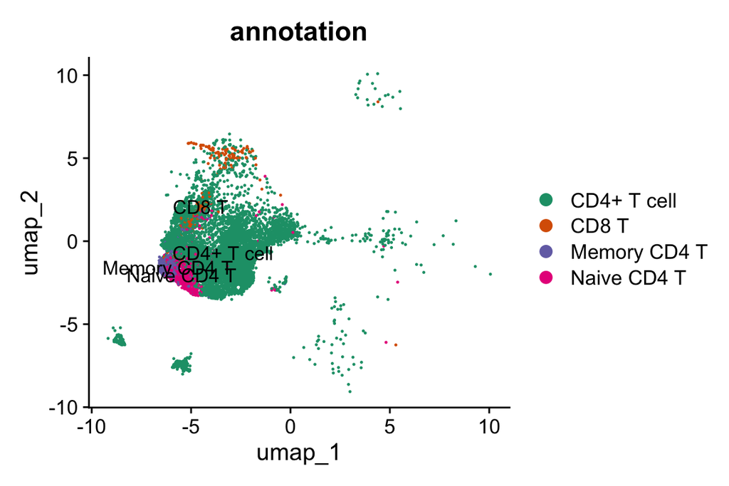

```r
library(RColorBrewer)
Seurat::DimPlot(
    se_t,
    group.by = "annotation",
    label = TRUE,
    cols = "Dark2",
    shuffle = TRUE)
```